# Lecture 2 Basic concepts

Sine Zambach  
2022

### Recap

- A bit of motivation for why we should program
- Assignment `x <- 3`
- Math operators (`+,-,/,*,^`)
- Logic operator (==, !=, >=, <=)
- Reading in files (in video + exercises)

### We have different data types

```r
class(TRUE) # Same as class(T) or class(true) but NOT class(True)
```

```
[1] "logical"
```

```r
class("Hello World")
```

```
[1] "character"
```

```r
class(1.5)
```

```
[1] "numeric"
```

```r
class(2021L)
```

```
[1] "integer"
```

### Data types manipulation (try it yourself)

You can also force data into other data types.

```r
as.character(1.5)
```

```
[1] "1.5"
```

```r
as.factor(TRUE)
```

```
[1] TRUE
Levels: TRUE
```

but you cannot make a characters numeric

```r
as.numeric("Hello World")
```

```
[1] NA
```

### Today

- Objects/variables and Data Structures
- Logic operators and conditions
- Using functions
- Debugging
- Slido-evaluation (2 min)

### One level up: Data structure

- How your data is stored
- How you can retrieve data

Examples

- *Atomic vectors*
- *Vectors*
- *Data.frames*
- Lists
- Matrices

### Vectors

Recall we looked at assigning 3 to x. This is an *atomic vector*. It is also a *variable* or an *object*

```r
A <- 3
```

We could also assign more values at a time. This creates a *vector* using the important function **`c()`**:

```r
C <- c(2,4,6,8) # Notice it is a small c!
C
```

```
[1] 2 4 6 8
```

You can get a value out of a vector using index-brackets

```r
C[3] # what value?
```

```
[1] 6
```

### Vector and data types

You cannot mix data types in one vector

```r
K <- c(2,4,6,"hello")
K
```

```
[1] "2"     "4"     "6"     "hello"
```

```r
class(K) # What class will this be?
```

```
[1] "character"
```

### Manipulating vectors

1. You can change a value in a vector also using the brackets

```r
C[3] <- 100
C         # What is now the vector?
```

```
[1]   2   4 100   8
```

1. You can add an extra element

```r
C <- append(C, 10, after = 1)
C
```

```
[1]   2  10   4 100   8
```

1. you can remove an element

```r
C[-5]
```

```
[1]   2  10   4 100
```

### Data.frame data structure

- Maybe the most advanced data type you need to learn
- Tabular format - similar to Excel-sheets
- Only one data type per column! Each column is a variable or a vector

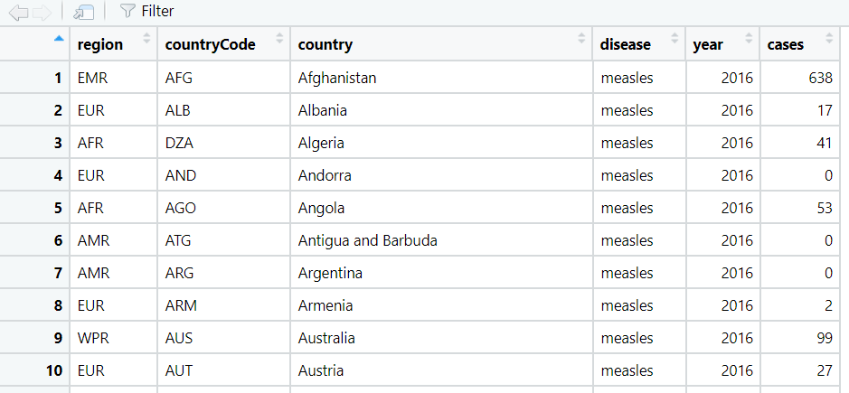

### Example of data.frame() - creating a data frame

When you read an Excel-sheet in - it ends in a data frame. You can also create one:

```r
letters <- sample(LETTERS[1:3], 10, replace = TRUE) # Sampling random data
D <- data.frame(1, 1:10, letters)
D
```

```
   X1 X1.10 letters
1   1     1       C
2   1     2       C
3   1     3       A
4   1     4       C
5   1     5       A
6   1     6       A
7   1     7       A
8   1     8       A
9   1     9       B
10  1    10       C
```

### Getting data out of data.frames

There are different way you can access rows, columns and single cells:

```r
D[,1] # Like the A-column in Excel
```

```
 [1] 1 1 1 1 1 1 1 1 1 1
```

```r
D$X1
```

```
 [1] 1 1 1 1 1 1 1 1 1 1
```

```r
D[1,] # Like first row in Excel
```

```
  X1 X1.10 letters
1  1     1       C
```

```r
D[1,3] # Like C1 in Excel. Now, extract 5th element in X1.10 ("5")
```

```
[1] "C"
```

### Manipulation of data.frames

You can add a new value

```r
D[1,3] <- "M"
D[1,]
```

```
  X1 X1.10 letters
1  1     1       M
```

You can subset (you will learn an easier function for this later)

```r
ND <- D[D$letters == "C", ] # New DF with only C in "letter"
mean(ND[, 2])
```

```
[1] 5.333333
```

```r
mean(D[, 2])
```

```
[1] 5.5
```

### Other data structures you will meet: List and Matrix

If you have a list of different data types you can use **`list()`**:

```r
L <- list(2,4,"hello",TRUE)
```

Matrix - when you have only one data type in your table

```r
M <- matrix(c(1,2,3,4,5,6),ncol=2, nrow=3)
M
```

```
     [,1] [,2]
[1,]    1    4
[2,]    2    5
[3,]    3    6
```

### Operators

**Math operators returns a number**

| Operator | Meaning |
| --- | --- |
| + | Addition |
| - | Subtraction |
| / | Division |
| * | Multiplication |
| ^ | Exponentiation |

**Logic operators returns TRUE/FALSE/NA**

| Operator | Meaning |
| --- | --- |
| == | Equal |
| != | NOT equal |
| <= | Less than or equal |
| >= | Greater than or equal |
| a \|\| b | either a OR b |
| a && b | both a AND b |
| !a | NOT a |
| %in% | Equal to one of elements |

### Logic operators are often used to test for TRUE/FALSE

Here are some examples of usages

```r
x <- 3
y <- 6

x!=y        # NOT Equals
```

```
[1] TRUE
```

```r
x==y || x<=y # OR
```

```
[1] TRUE
```

```r
x==y && x<=y # AND
```

```
[1] FALSE
```

Logic operators are often used in *Conditions*…

### Conditions

- What makes a computer program operational and more than a “calculator” or markup language like HTML
- Comes in different flavors of `if`, `then` and `else`
- An `if`-statement allows you to conditionally execute code.

It has a structure like this:

```r
if (condition) {
  # code executed when condition is TRUE
} else {
  # code executed when condition is FALSE
}
```

Let us put conditions and logical operators together!

### Conditions using our logical operators

Simple statement (recall `x is 3` and `y is 6`)

```r
if (x==y) {
  print("Yay")
} else {
   print("Nay")
}
```

```
[1] "Nay"
```

Can, btw also be written:

```r
ifelse(x==y, "Yay", "Nay")
```

```
[1] "Nay"
```

Try to change to one “=”. Ant to “not equal”

Using a more complex operator to compare of comparisons

```r
if (x<y && !(x %in% y)){
  print("This is true")
} else{
  print("Not so true")
}
```

```
[1] "This is true"
```

### Nested conditions

In nested conditions, we have a hierarchy of statements we test, and it has the structure:

```r
if (this) {
  # do something
} else {
  if (that) {
    # do something else
  } else {
    # now do something completely different
  }
}
```

Let us look at it

### Nested conditions - example

```r
if (x==y) {
  print("x is equal to y")
} else {
  if (x > y) {
    print("x is larger than y")
  } else {
    print("y is larger than x")
  }
}
```

```
[1] "y is larger than x"
```

### Nested conditions - the short version

We can also use our `ifelse()`-function

```r
ifelse(x==y, "x is equal to y",
       ifelse(x > y,"x is larger than y", "y is larger than x" ))
```

```
[1] "y is larger than x"
```

### Using functions - in one slide

We have now tried different functions. Next time we will learn more…

You use them like:

`function(Arg1, Arg2, Arg3...)`

```r
x <- c(1,2,4)

mean(x)
```

```
[1] 2.333333
```

```r
x <- c(1,2,4, NA)
mean(x, na.rm = TRUE)
```

```
[1] 2.333333
```

Try to look a function up. Is could be `mean()`. Or `sample()`

### Debugging

Video on advanced debugging in R on Canvas

But here is a need to know:

- Look at error message
- print, print, print
- Look for cheat sheets
- Search on your error - you will end on “Stack-overflow”
- Use Help (in lower right pane)
- Use ChatGPT (if code is not confidential)

[figure not shown]

Restart R-session:

Ctrl + Shift + F10

### Example 1 - look at error message:

```r
x <- 123
X
```

Will not run, so I have added `, eval=FALSE` in the chunk-header.

Demo…

### Example 2 - print and investigate

```r
x <- c(9,2.4)
x[1]
```

```
[1] 9
```

```r
length(x)
```

```
[1] 2
```

```r
x[2]
```

```
[1] 2.4
```

### Example 3 - google

Sometimes it is pretty much nonsense:

`> library(tidyverse)`

```
 namespace ‘cli’ 3.2.0 is already loaded, but >= 3.3.0 is required
```

Someone had a similar problem before. Notice it is the cli-package in your problem and scales in the stack overflow site.

https://community.rstudio.com/t/problems-with-tidyverse-load-error-package-or-namespace-load-failed-for-tidyverse-in-loadnamespace-i-c-lib-loc-libpaths-versioncheck-vi-i-namespace-scales-0-4-0-is-already-loaded-but-0-4-1-is-required/3414